# STAT5003 Project Stage 2

Group 6

2023-04-26

```r
library(rpart)
library(ipred)
library(dplyr)
library(caret)
library(ranger)
library(corrplot)
library(forcats)
library(xgboost)
library(e1071)
library(ggplot2)

FIND_BEST_PARAMS <- FALSE
```

# 1 Overview

## 1.1 Introduction

With the widespread use of cars as a means of transportation, road accidents have become a significant issue that affects people’s lives and safety. While automobiles bring convenience to our lives, they also inevitably lead to a large number of traffic accidents. To mitigate the impact of road accidents, it is important to identify and understand the factors that lead to accidents. The severity of road traffic accidents is usually divided into four categories: fatal, serious, minor, and unknown, based on various influencing factors such as weather conditions, road type, number of vehicles involved, time of day, etc. However, in most cases, relevant departments can only learn the details of the accident at the scene, which wastes precious rescue time. Therefore, our team aimed to develop a model that can classify accidents based on their severity. By providing useful information for formulating appropriate measures to prevent accidents and mitigate their effects, we hope to make a positive impact on society.

## 1.2 Data Description

Our team selected a detailed UK road safety dataset from 2005 to 2014, including documentation of Accidents, Vehicles and Casualties. The original datasets were large, with 1.6 million, 3M and 2.2 million instances, with 32, 22 and 15 features per section respectively. We merge Vehicles with Accidents by “Accident_Index” and then merge it with Casualties by (“Accident_Index”, “Vehicle_Reference”). After merging, the final dataset consists of 3.3M rows and 66 columns. “Accident_Severity” is target which is what we need to predict.

```r
#df.ac <- read.csv("Accidents0514.csv")
#df.ve <- read.csv("Vehicles0514.csv")
#df.ca <- read.csv("Casualties0514.csv")
#df.1 <- merge(df.ve, df.ac, by = 'Accident_Index')
#df.res <- merge(df.1, df.ca, by = c("Accident_Index", "Vehicle_Reference"), all.x = TRUE)

#write.csv(df.res, "df_res.csv", row.names = FALSE)

df.res <- read.csv("df_res.csv")
```

## 1.3 Data Cleaning

We modify feature data types by converting some categories to factors and some numerical values to numeric. We also remove variables with excessive missing data and date variables. We address missing values by filling categorical variables with -1.

```r
set.seed(5003)
inTrain <- createDataPartition(df.res$Accident_Severity, p = .7)[[1]]
train <- df.res[inTrain, ]
test <- df.res[-inTrain, ]

ac.categorical_features <- c('Police_Force', 'Day_of_Week', 'Local_Authority_.District.', 'Local_Authority_.Highway.', 'X1st_Road_Class', 'X1st_Road_Number', 'Road_Type', 'Junction_Detail', 'Junction_Control', 'X2nd_Road_Number', 'Pedestrian_Crossing.Human_Control', 'Pedestrian_Crossing.Physical_Facilities', 'Light_Conditions', 'Weather_Conditions', 'Road_Surface_Conditions', 'Special_Conditions_at_Site', 'Carriageway_Hazards', 'Urban_or_Rural_Area', 'Did_Police_Officer_Attend_Scene_of_Accident', 'LSOA_of_Accident_Location')
ac.numerical_features <- c('Location_Easting_OSGR', 'Location_Northing_OSGR', 'Longitude', 'Latitude', 'Number_of_Vehicles', 'Number_of_Casualties', 'Speed_limit')

ve.categorical_features <- c('Vehicle_Type', 'Towing_and_Articulation', 'Vehicle_Manoeuvre', 'Vehicle_Location.Restricted_Lane', 'Junction_Location', 'Skidding_and_Overturning', 'Hit_Object_in_Carriageway', 'Vehicle_Leaving_Carriageway', 'Hit_Object_off_Carriageway', 'X1st_Point_of_Impact', 'Was_Vehicle_Left_Hand_Drive.', 'Journey_Purpose_of_Driver', 'Sex_of_Driver', 'Propulsion_Code', 'Driver_IMD_Decile', 'Driver_Home_Area_Type')
ve.numerical_features <- c('Age_of_Driver', 'Age_Band_of_Driver', 'Engine_Capacity_.CC.', 'Age_of_Vehicle')

ca.categorical_features <- c('Casualty_Class', 'Sex_of_Casualty', 'Casualty_Severity', 'Pedestrian_Location', 'Pedestrian_Movement', 'Car_Passenger', 'Bus_or_Coach_Passenger', 'Casualty_Type', 'Casualty_Home_Area_Type')
ca.numerical_features <- c('Age_of_Casualty', 'Age_Band_of_Casualty')

data_clean <- function(sample){

  sample <- sample %>% mutate_at(c(ve.categorical_features, ac.categorical_features, ca.categorical_features), as.factor)
  sample <- sample %>% mutate_at(c(ve.numerical_features, ac.numerical_features, ca.numerical_features), as.numeric)

  y <- sample$Accident_Severity
  sample <- sample %>% mutate_at("Accident_Severity", as.factor)

  #delete date and some features cos their percentage of missing value are over 0.4
  sample <- subset(sample, select = -c(Date,
                                       Pedestrian_Road_Maintenance_Worker,
                                       X2nd_Road_Class))

  # for categorical data, replace na with -1
  sample[, c(ve.categorical_features, ac.categorical_features)][is.na(sample[, c(ve.categorical_features, ac.categorical_features)])] <- -1

  # for numerical data, first replace -1 with na, and then replace na with a value which is picked randomly from the column.
  sample[, c(ve.numerical_features, ac.numerical_features)] <- replace(sample[, c(ve.numerical_features, ac.numerical_features)], sample[, c(ve.numerical_features, ac.numerical_features)] == -1, NA)
  sample[, c(ve.numerical_features, ac.numerical_features)] <- as.data.frame(lapply(sample[, c(ve.numerical_features, ac.numerical_features)], function(x) {
    if (any(is.na(x))) {
      x[is.na(x)] <- sample(x[!is.na(x)], sum(is.na(x)), replace = TRUE)
    }
    return(x)
  }))

  return (sample)
}

train.clean <- data_clean(train)
test.clean <- data_clean(test)
```

## 1.4 Data Analysis

### 1.4.1 Correlation Heatmap

A correlation heatmap between features is generated. The correlation coefficient ranges from -1 to 1, with -1 indicating a completely negative correlation, 0 indicating no correlation and 1 indicating a completely positive correlation. From the diagram, we can get that the vast majority of the characteristics are almost independent of each other.

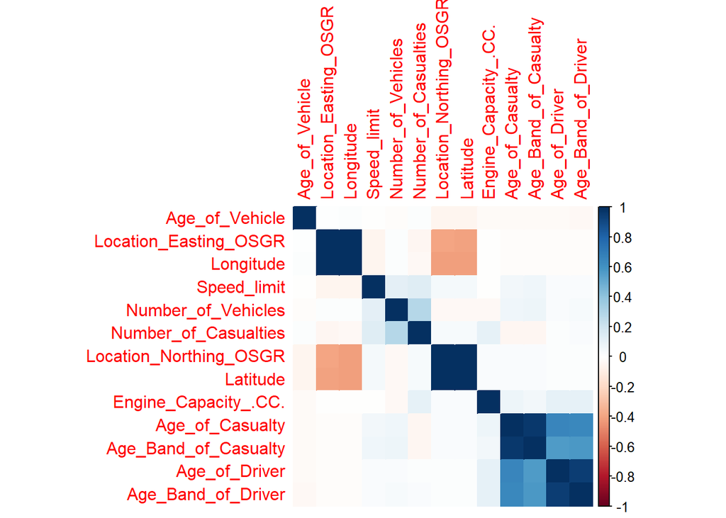

```r
cor.res = cor(train.clean[, c(ve.numerical_features, ac.numerical_features, ca.numerical_features)], use = "complete.obs")
corrplot(cor.res, method = 'color', order = 'hclust')
```

### 1.4.2 Target Distribution

The distribution of target is shown below. Based on it, we found that target of our dataset is unbalanced(1: fatal; 2: serious; 3: slight). In the real world, the number of slight car accidents is always much greater than the number of serious and fatal. So the unbalanced target is a huge challenge to our classifiers.

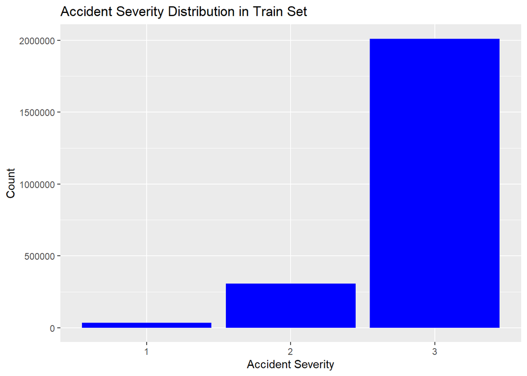

```r
train.label.counts <- as.data.frame(table(train.clean$Accident_Severity))

ggplot(train.label.counts, aes(x = Var1, y = Freq)) +
  geom_bar(stat = "identity", fill = "blue") +
  labs(title = "Accident Severity Distribution in Train Set",
       x = "Accident Severity",
       y = "Count")
```

## 1.5 Sampling

```r
set.seed(5003)
#train.1 <- train.clean[which(train.clean$Accident_Severity == 1), ][sample(dim(train.clean[which(train.clean$Accident_Severity == 1), ])[1], 30000, replace = FALSE), ]
#train.2 <- train.clean[which(train.clean$Accident_Severity == 2), ][sample(dim(train.clean[which(train.clean$Accident_Severity == 2), ])[1], 30000, replace = FALSE), ]
#train.3 <- train.clean[which(train.clean$Accident_Severity == 3), ][sample(dim(train.clean[which(train.clean$Accident_Severity == 3), ])[1], 30000, replace = FALSE), ]


#train <- rbind(train.1, train.2, train.3)

train <- train.clean[sample(nrow(train.clean), 0.1 * nrow(train.clean), replace = FALSE), ]
```

Due to a large amount of training set and the poor computationalality of our devices, we decided randomly select a tenth of the original training set as the new training set without stratification.

# 2 Feature engineering

Firstly, We transformed feature `Time` from char(“HH:MM”) to numeric(HH * 60 + MM) to make it to be a data type that can be calculated. Secondly, for categorical features, we count the number of their levels as follows. After that, variables with more than 50 unique values were removed because they are irrelevant and seems like identity of each instance, and it can also reduce the computational burden.

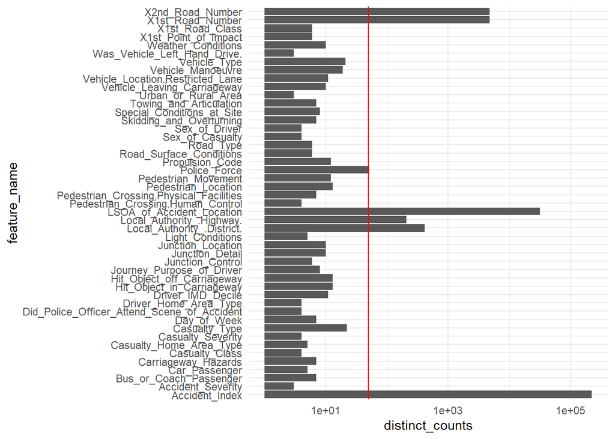

```r
train$Time <- sapply(train$Time, function(x) as.numeric(substr(x, 1, 2)) * 60 + as.numeric(substr(x, 4, 5)))

distinct_counts <- sapply(train, function(x) ifelse(is.factor(x) | is.character(x), n_distinct(x), 0))
train <- train[, which(distinct_counts <= 50)]

# plot
distinct_counts_factor <- distinct_counts[distinct_counts != 0]

ggplot(data.frame(feature_name = names(distinct_counts_factor), distinct_counts = unname(distinct_counts_factor)), aes(x = distinct_counts, y = feature_name)) +
  geom_col() +
  geom_vline(xintercept = 50, color = 'red') +
  scale_x_log10() +
  theme_minimal()
```

```r
# train
set.seed(5003)
shuffled_index <- sample(nrow(train))
train <- train[shuffled_index, ]

train_remove_na <- as.data.frame(lapply(train, function(x) {
    if(is.factor(x)){
        x <- addNA(x, ifany = TRUE)  # Add NA as a new level
        levels(x)[is.na(levels(x))] <- "-1"  # Replace NA level with "-1"
        return(x)
    } else {
        return(replace(x, is.na(x), -1))
    }
}))

train[] <- lapply(train, function(x) if(is.factor(x)) as.integer(x) else x)

# test
test <- test.clean[, colnames(train)]
test$Time <- sapply(test$Time, function(x) as.numeric(substr(x, 1, 2)) * 60 + as.numeric(substr(x, 4, 5)))

test_remove_na <- as.data.frame(lapply(test, function(x) {
    if(is.factor(x)){
        x <- addNA(x, ifany = TRUE)  # Add NA as a new level
        levels(x)[is.na(levels(x))] <- "-1"  # Replace NA level with "-1"
        return(x)
    } else {
        return(replace(x, is.na(x), -1))
    }
}))

test[] <- lapply(test, function(x) if(is.factor(x)) as.integer(x) else x)
```

Figure . Distinct counts of categorical features

Different models have different characteristics. XGBoost and Naive Bayes can handle missing values, but ranger can not. So we divided the dataset into those with missing values and those without missing values. For those dataset without missing values, we fill missing values with “-1” if the feature is factor, otherwise, -1.

# 3 Classification Algorithms

## 3.1 XGBOOST

### 3.1.1 Methodology

XGBoost is short for eXtreme Gradient Boosting, which is, obviously based on gradient boosting algorithm. Gradient boosting is an ensemble method that constructs a strong model by combining multiple weak models (usually decision trees). And the main idea of boosting algorithm is that trees are grown sequentially, and each tree is grown using information from previously grown trees. Specifically, in gradient boosting, the model is constructed through a series of iterations. In each iteration, the model will compensate for the weaknesses of its predecessors. The predictions of the new model are added to the predictions of the previous models to obtain the ensemble predictions of all the current models. XGBoost, created by Tianqi Chen, is a library for high performance(faster and more accurate) gradient boosting models. In addition, XGBoost supports regularization, which can help to avoid overfitting. Also, XGBoost can handle missing data. Since we are dealing with a multi-classification task with a big dataset, which has a large amount of missing data, XGBoost is a good choice.

### 3.1.2 Hyperparameter Tuning

In order to improve the performance of our model, XGBoost has many hyperparameters to tune as follows:

- `nrounds`: one of the most important parameters. It means max number of boosting iterations. In each iteration, the model will create a new decision tree. If nrounds is increasing, the model’s complexity will increase, which can improve the performance, also can cause overfitting. So, nrounds should be choosed carefully. Usually, nrounds and eta are seen as a pair to control the complexity of model. But in this case, we fix eta, use cross-validation to find the best iteration of each etas.
- `eta`: one of the most important parameters. It control the learning rate: scale the contribution of each tree by a factor of 0 < eta < 1 when it is added to the current approximation. So, low eta value means model will learn slowly even not enough when stop training, which might cause underfitting. In contrast, large eta means model will learn fast even too much when stop training, which might cause overfitting or skip the minimum point. (tune range: 0.05, 0.1, 0.2, 0.3)
- `max_depth`: maximum depth of a tree. The larger max depth, the more complex the model, and the more information model can catch, and the more likely to cause overfitting. (tune range: 4, 5, 6, 7, 8)
- `min_child_weights`: minimum sum of instance weight (hessian) needed in a child. If the tree partition step results in a leaf node with the sum of instance weight less than min_child_weight, then the building process will give up further partitioning. Large min child weights can be used to prevent overfitting, but if it is too large, it may cause underfitting. (tune range: 1, 2, 3, 4, 5)
- `subsample`: subsample ratio of the training instance. Setting it to 0.5 means that xgboost randomly collected half of the data instances to grow trees. By randomly selecting a subset of the data for training, the model’s variance can be reduced, thus preventing overfitting. However, if the subsample value is set too small, it may cause the model training to be unstable. (tune range: 0.5, 0.6, 0.7, 0.8, 0.9, 1)
- `colsample_bytree`: subsample ratio of columns when constructing each tree. Similar to subsample. (tune range: 0.5, 0.6, 0.7, 0.8, 0.9, 1)
- `gamma`: minimum loss reduction required to make a further partition on a leaf node of the tree. the larger, the more conservative the algorithm will be. This parameter can be used to prevent overfitting, but if set too small, it may cause underfitting. (tune range: 0, 1, 2, 3, 4, 5)

To find the best parameters combination, we tune the parameters(except `nrounds`) one by one(grid search is too complex(O(n^k), k is the number of parameters, n is the number of values of each parameter) to compute). And use mean `auc`(Area Under the Curve) to evaluate the models considering the target of dataset is unbalanced. After finding the best parameters combination, we use cross-validation to find the best `nrounds`.

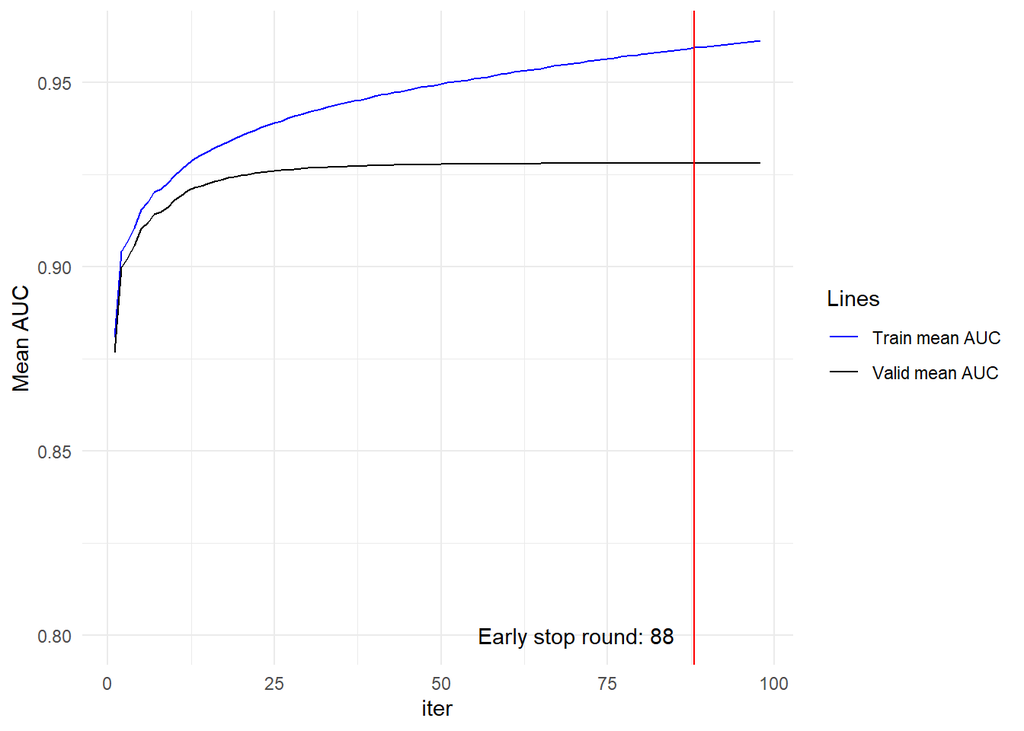

```r
set.seed(5003)

x_train <- train
x_train$Accident_Severity <- NULL
y_train <- train$Accident_Severity
x_test <- test
x_test$Accident_Severity <- NULL
y_test <- test$Accident_Severity

xgb_train <- xgb.DMatrix(as.matrix(x_train), label = y_train-1)

if(FIND_BEST_PARAMS == TRUE){
    params <- list(
      objective = "multi:softmax",
      eval_metric = "auc",
      num_class = 3
    )

    etas <- c(0.05, 0.1, 0.2, 0.3)
    max_depths <- c(4, 5, 7, 8)  # default: 6
    min_child_weights <- c(2, 3, 4, 5)  # default: 1
    subsamples <- c(0.5, 0.6, 0.7, 0.8, 0.9)  # default: 1
    colsample_bytrees <- c(0.5, 0.6, 0.7, 0.8, 0.9)  # default: 1
    gammas <- c(1, 2, 3, 4, 5)  # default: 0

    find_forward <- function(params, param_to_tune, param_name){
        best_auc <- 0
        for(param in param_to_tune){
            params[param_name] <- param

            cv_model <- xgb.cv(
              params = params,
              data = xgb_train,
              nrounds = 1000,
              nfold = 10,
              showsd = TRUE,
              stratified = TRUE,
              print_every_n = 10,
              early_stopping_rounds = 10,
              maximize = TRUE
            )

            mean_auc <- max(cv_model$evaluation_log$test_auc_mean)

            if (mean_auc > best_auc) {
                best_auc <- mean_auc
                best_param <- param
            }
        }
        params[param_name] <- best_param
        params
    }


    params <- find_forward(params, etas, 'eta')
    params <- find_forward(params, max_depths, 'max_depth')
    params <- find_forward(params, min_child_weights, 'min_child_weight')
    params <- find_forward(params, subsamples, 'subsample')
    params <- find_forward(params, colsample_bytrees, 'colsample_bytree')
    params <- find_forward(params, gammas, 'gamma')

    params  # eta = 0.2, max_depth = 8, min_child_weight = 3, subsample = 0.9, colsample_bytree = 0.6, gamma = 2
}

params <- list(
  objective = "multi:softmax",
  eval_metric = "auc",
  num_class = 3,
  max_depth = 8,
  eta = 0.2,
  gamma = 2,
  min_child_weight = 3,
  subsample = 0.9,
  colsample_bytree = 0.6
)

cv_model <- xgb.cv(
  params = params,
  data = xgb_train,
  nrounds = 1000,
  nfold = 10,
  showsd = TRUE,
  stratified = TRUE,
  print_every_n = 1,
  early_stopping_rounds = 10,
  maximize = TRUE,
  verbose = FALSE
)

best_iteration <- cv_model$best_iteration

ggplot() +
  geom_line(data = cv_model$evaluation_log, aes(x = iter, y = train_auc_mean, color = 'Train mean AUC')) +
  geom_line(data = cv_model$evaluation_log, aes(x = iter, y = test_auc_mean, color = 'Valid mean AUC')) +
  geom_vline(xintercept = cv_model$best_iteration, color = 'red') +
  annotate("text", x = cv_model$best_iteration, y = 0.8, label = paste0("Early stop round: ", cv_model$best_iteration), hjust = 1.1) +
  labs(y = 'Mean AUC', color = "Lines") +
  scale_color_manual(values = c('Train mean AUC' = 'blue', 'Valid mean AUC' = 'black')) +
  theme_minimal()
```

Figure. train and test mean AUC of each iteration

From the picture, we can see that after the best iteration(early stop point), test mean AUC does not increase even train mean AUC is increasing.

### 3.1.3 Final Model And Result

After parameter tuning, we obtain the optimal model based on the `auc`. The best parameter combination is eta = 0.2, max_depth = 8, min_child_weight = 3, subsample = 0.9, colsample_bytree = 0.6 and gamma = 2.

```r
final_xgb_model <- xgb.train(params, xgb_train, nrounds = best_iteration)

xgb_test <- xgb.DMatrix(as.matrix(x_test), label = y_test)
xgb_pred <- predict(final_xgb_model, xgb_test)
xgb_confusion_matrix <- confusionMatrix(as.factor(xgb_pred), as.factor(y_test - 1))
xgb_confusion_matrix$overall['Accuracy']
```

```
##  Accuracy
## 0.9345739
```

```r
xgb_confusion_matrix$byClass[, "F1"]
```

```
##  Class: 0  Class: 1  Class: 2
## 0.6495270 0.7102575 0.9644484
```

```r
xgb.f1_score <- mean(xgb_confusion_matrix$byClass[, "F1"])
```

Test final model on the test set and get the result. F1 scores of each class are 0.650, 0.710, 0.964. Accuracy is 0.935. More details in Model comparison.

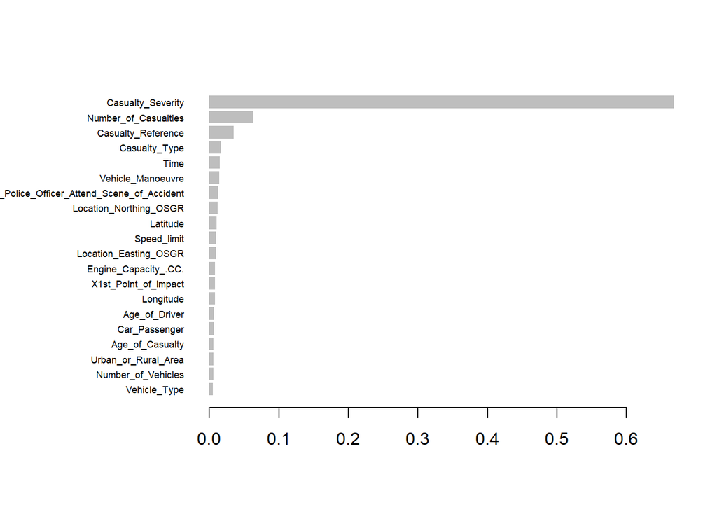

```r
mat <- xgb.importance(feature_names = colnames(as.matrix(x_train)), model = final_xgb_model)
xgb.plot.importance(importance_matrix = mat[1:20])
```

Figure . Feature importance

Feature importance is generated automatically by XGBoost showing features from most important to least top to bottom.

## 3.2 RANDOM FOREST

### 3.2.1 Methodology

The method used in this part is random forest for classification. Random forest is an ensemble learning method based on decision trees, which constructs multiple decision trees by randomly selecting features and samples and combining them to obtain the final classification result.

Random Forest has the following advantages for processing large datasets:

- `Efficiency`: Since Random Forest can process multiple decision trees in parallel, it can efficiently process large datasets. In addition, the splitting process of random forest can be accelerated by randomly selecting features and samples, which further improves the efficiency of processing large data sets.
- `Scalability`: Since Random Forest can process datasets in parallel, it can easily scale up to large datasets. Also, since Random Forest is not limited by the feature space, it can handle high-dimensional datasets.
- `Robustness`: Since random forest uses multiple decision trees for classification, it can reduce the overfitting and interference of a single decision tree, thereby improving the robustness of the model.

### 3.2.2 Hyperparameter Tuning

First, we define some parameter ranges, including the number of features used for node splitting of each tree (mtry_range), the number of trees (ntree_range), the minimum number of observations of nodes (min.node.size_range) and the maximum depth of the tree (max. depth_range).

Next, use the random forest algorithm to train multiple models, and record the Out-Of-Bag (OOB) error rate of each model. Among them, the mtry parameter is set to the value in the current cycle, while the other parameters are respectively set to the preset default values. By looping through the calculation of the OOB error for each parameter, the code is able to find the optimal model for each parameter setting.

Finally, the optimal parameter values are returned, including the optimal mtry value (optimal_mtry), the optimal ntree value (optimal_ntree), the optimal min.node.size value (optimal_min.node.size) and the optimal max .depth value (optimal_max.depth).

```r
if(FIND_BEST_PARAMS){

    # Find best mtry
    # Train multiple models with different values for mtry and record the OOB errors
    mtry_range <- c(5, 10, 15, 20, 25, 30)
    oob_errors <- vector("double", length = length(mtry_range))

    for (i in seq_along(mtry_range)) {
        model <- ranger(Accident_Severity ~ ., data = train_remove_na, mtry = mtry_range[i])
        oob_errors[i] <- model$prediction.error
    }

    # Find the mtry value with the minimum OOB error
    optimal_mtry <- mtry_range[which.min(oob_errors)]
    optimal_mtry #10

    #Find best ntree
    ntree_range <- seq(from = 200, to = 1000, by = 200)
    oob_errors <- numeric(length(ntree_range))

    for (i in seq_along(ntree_range)) {
        model <- ranger(Accident_Severity ~ ., data = train_remove_na, num.trees = ntree_range[i], mtry = 10)
        oob_errors[i] <- model$prediction.error
    }

    optimal_ntree <- ntree_range[which.min(oob_errors)]
    optimal_ntree #600


    #Find the best min.node.size
    min.node.size_range <- seq(1, 10, by = 1)
    oob_errors <- rep(0, length(min.node.size_range))

    for (i in 1:length(min.node.size_range)) {
        model <- ranger(Accident_Severity ~ ., data = train_remove_na,
                        mtry = 10, num.trees  = 600, min.node.size = min.node.size_range[i])

        oob_errors[i] <- model$prediction.error
    }

    optimal_min.node.size <- min.node.size_range[which.min(oob_errors)]
    optimal_min.node.size #2


    #Find the best max.depth
    max.depth_range <- c(10,15,20,25,30,35)
    oob_errors <-  numeric(length = length(max.depth_range))

    for (i in seq_along(max.depth_range)) {
        model <- ranger(Accident_Severity ~ ., data = train_remove_na,
                        mtry = 10, num.trees  = 600, min.node.size = 2, max.depth = max.depth_range[i])

        oob_errors[i] <- model$prediction.error
    }

    optimal_max.depth <- max.depth_range[which.min(oob_errors)]
    optimal_max.depth #25
}else{
    optimal_mtry = 10
    optimal_ntree =600
    optimal_min.node.size = 2
    optimal_max.depth = 25
}
```

### 3.2.3 Final Model And Result

A random forest model was trained using the best parameters found earlier (mtry = 10, num.trees = 600, min.node.size = 2, max.depth = 25) and used to make predictions on the test set. Next, use the `set.seed()` function to set the seed of the random number generator to ensure the repeatability of the results.

```r
#The final model which is after tuning parameter
set.seed(5003)
final_rf_model <- ranger(Accident_Severity ~ ., data = train_remove_na,
                       mtry = 10,
                       num.trees = 600,
                       min.node.size = 2,
                       max.depth = 25,
                       verbose = FALSE,
                       classification = TRUE)

rf_test_remove_na_y <- test_remove_na$Accident_Severity
rf_test_remove_na_x <- test_remove_na
rf_test_remove_na_x$Accident_Severity <- NULL

rf_pred <- predict(final_rf_model, rf_test_remove_na_x)$predictions
rf_confusion_matrix <- confusionMatrix(rf_pred, rf_test_remove_na_y)
rf_confusion_matrix$overall['Accuracy']
```

```
##  Accuracy
## 0.9349458
```

```r
rf_confusion_matrix$byClass[, "F1"]
```

```
##  Class: 1  Class: 2  Class: 3
## 0.6488074 0.7110130 0.9644961
```

```r
rf.f1_score <- mean(rf_confusion_matrix$byClass[, "F1"])
```

Use the `confusionMatrix()` function to calculate the confusion matrix between the prediction result and the target variable of the test set, and extract the overall accuracy rate and each category index from it. Finally with the model we get an accuracy of 0.935, and each class of f1 score 0.649, 0.711, 0.964. More details in Model comparison. More details in Model comparison.

## 3.3 DECISION TREE WITH BAGGING

### 3.3.1 Methodology

Decision tree is a commonly used classification algorithm that generates a tree-shaped model based on the given training dataset to make predictions on data. However, decision trees are prone to overfitting as they tend to model the training data too complexly. To overcome this problem, we use Bagging to solve the classification problem of this dataset. Bagging is an ensemble learning technique that can be used to reduce the overfitting impact of decision trees. Bagging can generate multiple training datasets by bootstrap sampling from the original dataset and then train multiple decision trees using these training datasets. The final prediction result is the voting result of all decision tree predictions.

### 3.3.2 Hyperparameter Tuning

Model Creation To address these issues, we utilize ranger to create decision trees with bagging models to improve computational performance and use f1 score as the evaluation metric to ensure proper model accuracy even in the presence of imbalanced samples.

```r
inTrain <- createDataPartition(train_remove_na$Accident_Severity, p = 0.8)[[1]]
tune_train <- train_remove_na[inTrain, ]
tune_valid <- train_remove_na[-inTrain, ]

y_tune_valid <- tune_valid$Accident_Severity
x_tune_valid <- tune_valid
x_tune_valid$Accident_Severity <- NULL


FIND_BEST_PARAMS <- FALSE

if(FIND_BEST_PARAMS){
    ntrees <- seq(100, 1000, by = 100)
    maxdepth <- c(10,20,30,40,50,NULL)

    f1_score <- matrix(NA, nrow = length(ntrees), ncol = length(maxdepth))

    for (i in seq_along(ntrees)) {
        for (j in seq_along(maxdepth)) {
            rf <- ranger(Accident_Severity ~ ., data = tune_train, num.trees = ntrees[i], max.depth = maxdepth[j], mtry =55)
            y_pred <- predict(rf, data = x_tune_valid)
            cm <- confusionMatrix(y_pred$predictions, y_tune_valid, mode = "prec_recall")
            f1_score[i,j] = mean(cm$byClass[,"F1"])
        }
    }

    best_depth <- maxdepth[which.max(apply(f1_score,2, max))]
    best_ntree <- ntrees[which.max(f1_score[which.max(f1_score[,which.max(apply(f1_score, 2, max))]),])]

} else {
  best_depth = 20
  best_ntree = 500
}
```

### 3.3.3 Final Model And Result

Creating the Best Model Using the Ranger algorithm (function ranger), we trained a classification model based on the training dataset train_ranger and performed bagging using 500 decision trees and all 55 features. We used `Accident_Severity`, the severity of traffic accidents, as the target variable, and the other variables as predictor variables.

```r
final_bagging_model <- ranger(Accident_Severity ~ ., data = train_remove_na, num.trees = 500, max.depth = 20, mtry =55, importance = "impurity", num.threads = 6,verbose = FALSE, classification = TRUE)

bagging_test_remove_na_y <- test_remove_na$Accident_Severity
bagging_test_remove_na_x <- test_remove_na
bagging_test_remove_na_x$Accident_Severity <- NULL

bagging_pred <- predict(final_bagging_model, bagging_test_remove_na_x)$predictions
bagging_confusion_matrix <- confusionMatrix(bagging_pred, bagging_test_remove_na_y)
bagging_confusion_matrix$overall['Accuracy']
```

```
##  Accuracy
## 0.9350995
```

```r
bagging_confusion_matrix$byClass[, "F1"]
```

```
##  Class: 1  Class: 2  Class: 3
## 0.6519220 0.7123804 0.9646070
```

```r
bagging.f1_score <- mean(bagging_confusion_matrix$byClass[, "F1"])
```

```r
imp <- cbind(row.names(final_bagging_model), importance(final_bagging_model))
imp <- imp[order(-imp[, 1]), ]

library(ggplot2)
imp = data.frame(imp)
# Create a data frame from the imp object
imp_df <- data.frame(Variable = row.names(imp), Importance = imp[,1])

# Reorder the levels of the Variable factor in descending order of Importance
imp_df$Variable <- reorder(imp_df$Variable, -imp_df$Importance)

# Plot the bar chart with reordered levels and vertical y-axis labels

imp_df$Percentage <- imp_df$Importance / sum(imp_df$Importance) * 100

importance_of_variables = ggplot(imp_df, aes(x=Variable, y=Percentage)) +
  geom_bar(stat="identity") +
  labs(title="Importance of Variables", x="Variable", y="Percentage") +
  theme(axis.text.x = element_text(angle = 90, vjust = 0.5, hjust=1))
```

Using the optimal parameters obtained above, namely num_tree = 500 and maxdepth = 20, we trained the model on the train set and tested it on the test set. The resulting F1 scores of each class were 0.652, 0.712, 0.965.

## 3.4 BAYES

### 3.4.1 Methodology

Naive Bayes is a classification algorithm based on probability statistics and Bayes theorem. The basic idea of the model is to learn the conditional probability of each feature for the classification result by using the data set of known features, and then perform classification prediction according to Bayesian theorem.

### 3.4.2 Feature Selection

In this model, we performed feature selection, and the reason for implementing feature selection engineering is because:

- It can simplify the model. Since our dataset contains a large number of features, the model is overly complex, increasing training time and computational cost.
- It can improve the performance of the model. Selecting a sub-dataset with a higher validation score can reduce the impact of noise and redundant information on the model, thereby improving the performance and generalization ability of the model.
- It speeds up training. Feature selection reduces the number of features, thereby reducing the computation time and resource consumption required to train the model. By removing irrelevant or redundant features, the training speed of the model can be accelerated, making the training on our dataset more efficient.

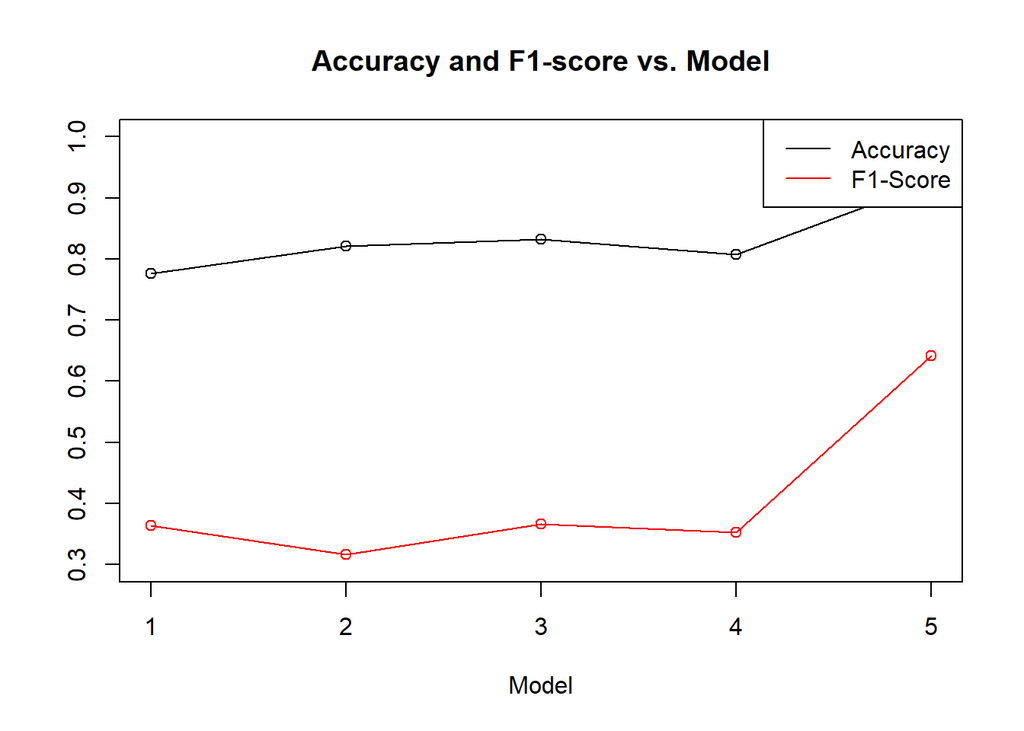

```r
set.seed(5003)
trainIndex <- createDataPartition(train$Accident_Severity, p = 0.9, list = FALSE)
nb_train <- train[trainIndex, ]
nb_valid <- train[-trainIndex, ]

nb_train_y <- as.factor(nb_train$Accident_Severity)
nb_valid_y <- as.factor(nb_valid$Accident_Severity)
nb_train$Accident_Severity <- NULL
nb_valid$Accident_Severity <- NULL


#first features group with 1-11 features
nb_train1.data <- nb_train[, 1:11]
nb_valid1.data <- nb_valid[, 1:11]
#second features group with 11-22 features
nb_train2.data <- nb_train[, 11:22]
nb_valid2.data <- nb_valid[, 11:22]
#third features group with 22-33 features
nb_train3.data <- nb_train[, 22:33]
nb_valid3.data <- nb_valid[, 22:33]
#fourth features group with 33-44 features
nb_train4.data <- nb_train[, 33:44]
nb_valid4.data <- nb_valid[, 33:44]
#fifth features group with 44-55 features
nb_train5.data <- nb_train[, 44:55]
nb_valid5.data <- nb_valid[, 44:55]

accuracy_list <- list()
f1_score_list <- list()

#model1
nb_model <- naiveBayes(nb_train1.data, nb_train_y, laplace = 0.1, na.action = na.exclude)
pred <- predict(nb_model, nb_valid1.data)

accuracy <- sum(pred == nb_valid_y) / length(nb_valid_y)
cm <- confusionMatrix(pred, nb_valid_y, mode = "everything")
f1_score <- cm$byClass[,"F1"]
avg_f1_score <- mean(f1_score)

accuracy_list[[1]] <- accuracy
f1_score_list[[1]] <- avg_f1_score

#model2
nb_model <- naiveBayes(nb_train2.data, nb_train_y, laplace = 0.1, na.action = na.exclude)
pred <- predict(nb_model, nb_valid2.data)

accuracy <- sum(pred == nb_valid_y) / length(nb_valid_y)
cm <- confusionMatrix(pred, nb_valid_y, mode = "everything")
f1_score <- cm$byClass[,"F1"]
avg_f1_score <- mean(f1_score)

accuracy_list[[2]] <- accuracy
f1_score_list[[2]] <- avg_f1_score

#model3
nb_model <- naiveBayes(nb_train3.data, nb_train_y, laplace = 0.1, na.action = na.exclude)
pred <- predict(nb_model, nb_valid3.data)

accuracy <- sum(pred == nb_valid_y) / length(nb_valid_y)
cm <- confusionMatrix(pred, nb_valid_y, mode = "everything")
f1_score <- cm$byClass[,"F1"]
avg_f1_score <- mean(f1_score)

accuracy_list[[3]] <- accuracy
f1_score_list[[3]] <- avg_f1_score

#model4
nb_model <- naiveBayes(nb_train4.data, nb_train_y, laplace = 0.1, na.action = na.exclude)
pred <- predict(nb_model, nb_valid4.data)

accuracy <- sum(pred == nb_valid_y) / length(nb_valid_y)
cm <- confusionMatrix(pred, nb_valid_y, mode = "everything")
f1_score <- cm$byClass[,"F1"]
avg_f1_score <- mean(f1_score)

accuracy_list[[4]] <- accuracy
f1_score_list[[4]] <- avg_f1_score

#model5
nb_model <- naiveBayes(nb_train5.data, nb_train_y, laplace = 0.1, na.action = na.exclude)
pred <- predict(nb_model, nb_valid5.data)

accuracy <- sum(pred == nb_valid_y) / length(nb_valid_y)
cm <- confusionMatrix(pred, nb_valid_y, mode = "everything")
f1_score <- cm$byClass[,"F1"]
avg_f1_score <- mean(f1_score)

accuracy_list[[5]] <- accuracy
f1_score_list[[5]] <- avg_f1_score


y <- 1:5

plot(y, accuracy_list, type = "o", xlab = "Model", ylab = "", main = "Accuracy and F1-score vs. Model", ylim = c(0.3, 1))
lines(y, f1_score_list, type = "o", col = "red")
legend("topright", legend = c("Accuracy", "F1-Score"), col = c("black", "red"), lty = 1)
```

Figure. Naive Bayes Accuracy and F1-score vs. Model

In this section, we divide the features of the dataset into five parts, each part contains different features, which can help us better understand the dataset, and each part represents different data characteristics. At the same time, the impact of different feature subsets on model performance can be compared, which will help us determine which features are more important for the model prediction.

### 3.4.3 Final Model And Result

As shown in the line chart above, the optimal feature subset is the fifth, which includes Casualty_Reference, Casualty_Class, Sex_of_Casualty, Age_of_Casualty, Age_Band_of_Casualty, Casualty_Severity, Pedestrian_Location, Pedestrian_Movement, Car_Passenger, Bus_or_Coach_Passenger, Casualty_Type, Casualty_Home_Area_Type. Use them to train a final model and then use test set to test the performance of this model.

```r
final_nb_model <- naiveBayes(nb_train5.data, nb_train_y, laplace = 0.1, na.action = na.exclude)
nb_test_y <- as.factor(test$Accident_Severity)
nb_test_x <- test
nb_test_x$Accident_Severity <- NULL
nb_test_x <- nb_test_x[, 44:55]

nb_pred <- predict(final_nb_model, nb_test_x)
nb_confusion_matrix <- confusionMatrix(nb_pred, nb_test_y)
nb_confusion_matrix$overall['Accuracy']
```

```
##  Accuracy
## 0.9270323
```

```r
nb_confusion_matrix$byClass[, "F1"]
```

```
##  Class: 1  Class: 2  Class: 3
## 0.3213081 0.6914963 0.9616580
```

```r
nb.f1_score <- mean(nb_confusion_matrix$byClass[, "F1"])
```

Test final model on the test set and get the result. F1 scores of each class are 0.321, 0.691, 0.962. Accuracy is 0.927. More details in Model comparison.

# 4 Model Comparison

```r
bagging_byclass <- data.frame(bagging_confusion_matrix$byClass,metric = rownames(bagging_confusion_matrix$byClass))
bagging_byclass$model <- "DT with bagging"
rf_byclass <- data.frame(rf_confusion_matrix$byClass,metric = rownames(rf_confusion_matrix$byClass))
rf_byclass$model <- "random forest"

nb_byclass <- data.frame(nb_confusion_matrix$byClass,metric = rownames(nb_confusion_matrix$byClass))
nb_byclass$model <- "Naive Bayes"

new_rownames <- gsub("2", "3", rownames(xgb_confusion_matrix$byClass))
new_rownames <- gsub("1", "2", new_rownames)
new_rownames <- gsub("0", "1", new_rownames)

xgb_byclass <- data.frame(xgb_confusion_matrix$byClass,metric = new_rownames)
xgb_byclass$model <- "XGboosting"

confusion_df <- rbind(rf_byclass, bagging_byclass,nb_byclass,xgb_byclass)
```

```r
library(ggplot2)
library(reshape2)
# class 1
confusion_df_class1 <- subset(confusion_df, metric == "Class: 1")


confusion_df_class1_melt <- melt(confusion_df_class1, id.vars = c("model", "metric"))


confusion_df_class1_precision <- subset(confusion_df_class1_melt, variable == "Precision")
confusion_df_class1_recall <- subset(confusion_df_class1_melt, variable == "Recall")
confusion_df_class1_f1 <- subset(confusion_df_class1_melt, variable == "F1")
#confusion_df_class1_Accuracy <- subset(confusion_df_class1_melt, variable == "Balanced.Accuracy")

confusion_df_class1_combined <- rbind(confusion_df_class1_precision, confusion_df_class1_recall, confusion_df_class1_f1)

plot.class_1 <- ggplot(confusion_df_class1_combined, aes(x = variable, y = value, fill = model)) +
  geom_bar(stat = "identity", position = position_dodge(), width = 0.8) +
  geom_text(aes(label = round(value, 2)), position = position_dodge(width = 0.8), vjust = -0.5) +
  labs(x = "Precision/Recall/F1 Score", y = "Accuracy", fill = "Model", title = "Class: 1") +
  theme_minimal()



#class 2
confusion_df_class2 <- subset(confusion_df, metric == "Class: 2")


confusion_df_class2_melt <- melt(confusion_df_class2, id.vars = c("model", "metric"))


confusion_df_class2_precision <- subset(confusion_df_class2_melt, variable == "Precision")
confusion_df_class2_recall <- subset(confusion_df_class2_melt, variable == "Recall")
confusion_df_class2_f1 <- subset(confusion_df_class2_melt, variable == "F1")
#confusion_df_class2_Accuracy <- subset(confusion_df_class2_melt, variable == "Balanced.Accuracy")

confusion_df_class1_combined <- rbind(confusion_df_class2_precision, confusion_df_class2_recall, confusion_df_class2_f1)

plot.class_2 <- ggplot(confusion_df_class1_combined, aes(x = variable, y = value, fill = model)) +
  geom_bar(stat = "identity", position = position_dodge(), width = 0.8) +
  geom_text(aes(label = round(value, 2)), position = position_dodge(width = 0.8), vjust = -0.5) +
  labs(x = "Precision/Recall/F1 Score", y = "Accuracy", fill = "Model", title = "Class: 2") +
  theme_minimal()

#class 3
confusion_df_class3 <- subset(confusion_df, metric == "Class: 3")


confusion_df_class3_melt <- melt(confusion_df_class3, id.vars = c("model", "metric"))


confusion_df_class3_precision <- subset(confusion_df_class3_melt, variable == "Precision")
confusion_df_class3_recall <- subset(confusion_df_class3_melt, variable == "Recall")
confusion_df_class3_f1 <- subset(confusion_df_class3_melt, variable == "F1")
#confusion_df_class3_Accuracy <- subset(confusion_df_class3_melt, variable == "Balanced.Accuracy")

confusion_df_class1_combined <- rbind(confusion_df_class3_precision, confusion_df_class3_recall, confusion_df_class3_f1)

plot.class_3 <- ggplot(confusion_df_class1_combined, aes(x = variable, y = value, fill = model)) +
  geom_bar(stat = "identity", position = position_dodge(), width = 0.8) +
  geom_text(aes(label = round(value, 2)), position = position_dodge(width = 0.8), vjust = -0.5) +
  labs(x = "Precision/Recall/F1 Score", y = "Accuracy", fill = "Model", title = "Class: 3") +
  theme_minimal()
```

## 4.1 Performance

We used decision tree with bagging, random forest, XGBoost, and Naïve Bayes to process the data. For each algorithm, we generated the best model using the optimal parameters obtained above and evaluated the classification ability of the four models on Class 1, 2, and 3, respectively.

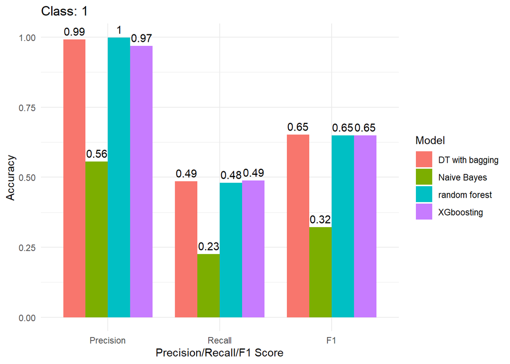

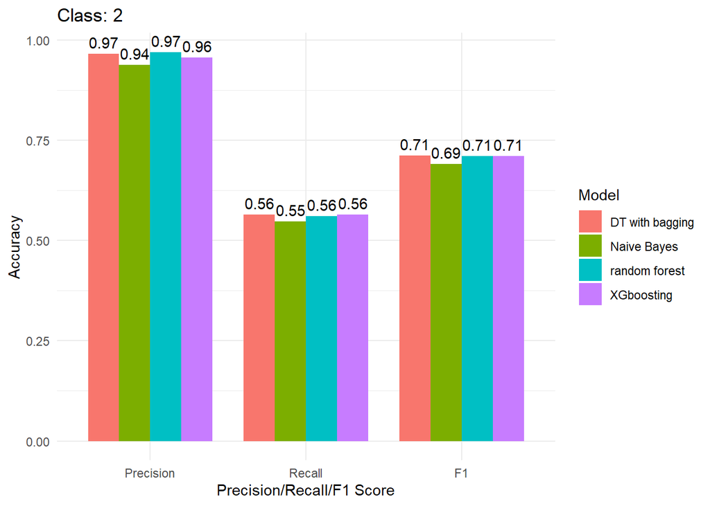

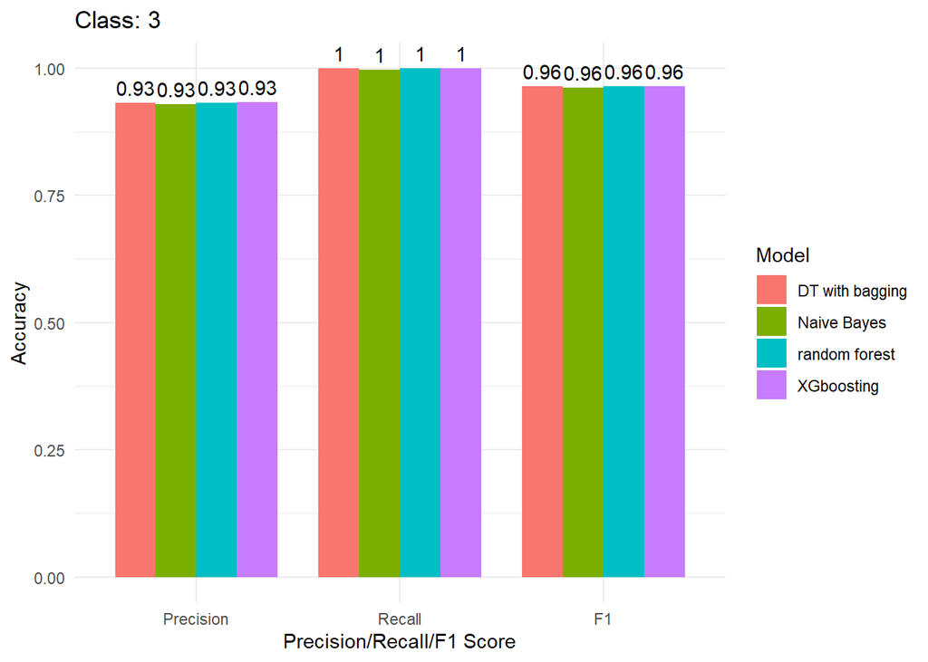

| Measurement | XGBoost | Random Forest | Decision tree with bagging | Bayes |
| --- | --- | --- | --- | --- |
| Accuracy | 0.935 | 0.935 | 0.935 | 0.927 |
| Mean Precision | 0.952 | 0.967 | 0.963 | 0.807 |
| Mean Recall | 0.684 | 0.680 | 0.683 | 0.590 |
| Macro F1 score | 0.775 | 0.775 | 0.776 | 0.658 |

Overall, the classification ability of the above four models in Class 1 is not good, which may be due to the relatively small number of examples in Class 1 compared to other categories, making it harder for classifiers to learn effective information for Class 1. Compared to Class 1, classification ability in Class 2 is slightly better. All classifiers perform very well in identifying instances belonging to Class 3.

The figure and data above show that the classifiers of the four models perform relatively poorly in Class 1 and Class 2, but relatively well in Class 3. The three tree models(XGBoost, Random Forest, Decision tree with bagging) perform almost identically, but have a significant advantage over Naive Bayes.

### 4.1.1 Accuracy

The accuracy of all models is very high, about 93%. However, test set is pretty unbalanced, even if our predictions are all class 3, the accuracy can be very high as well. In this case, accuracy seems meaningless.

### 4.1.2 Precision

XGBoost, Random Forest, Decision tree with bagging are almost same, and better than Bayes.

### 4.1.3 Recall

`Recall = TP / (TP + FN)`. Recall focuses on how many positive instances can be truly predicted. This is an important evaluation because we want to predict fatal and serious accidents as much as possible.

- Class 1(fatal): all recalls are low, which means that so many fatal accidents are predicted as other accident severity. Bayes(0.226) are worse than other three(XGBoost: 0.489; Random Forest: 0.480; Decision tree with bagging: 0.486).
- Class 2(Serious): all recalls are low as well, which means that so many Serious accidents are predicted as other accident severity. And four recalls are almost same(XGBoost: 0.565; Random Forest: 0.561; Decision tree with bagging: 0.564; Bayes: 0.548).
- Class 3(Slight): all recalls are almost 100%.

XGBoost, Random Forest, Decision tree with bagging are almost same, and better than Bayes.

### 4.1.4 F1 Score

`F1 = 2 * (Precision * Recall) / (Precision + Recall)`. F1 Score is a good evaluation that combines Precision and Recall. Only if Precision and Recall are high, F1 Score will be high. So it can be a good evaluation to assess how well the model performs when the dataset are unbalanced.

XGBoost, Random Forest, Decision tree with bagging are almost same, and better than Bayes.

## 4.2 Confusion Matrix

| RandomForest | Class 1 | Class 2 | Class 3 | DT bagging | Class 1 | Class 2 | Class 3 |
| --- | --- | --- | --- | --- | --- | --- | --- |
| Class 1 | 7290 | 5 | 0 | Class 1 | 7369 | 50 | 11 |
| Class 2 | 2143 | 73635 | 117 | Class 2 | 2174 | 74058 | 453 |
| Class 3 | 5744 | 57592 | 861879 | Class 3 | 5634 | 57124 | 861532 |

| Naives Bayes | Class 1 | Class 2 | Class 3 | XGboost | Class 1 | Class 2 | Class 3 |
| --- | --- | --- | --- | --- | --- | --- | --- |
| Class 1 | 3429 | 1557 | 1181 | Class 1 | 7415 | 186 | 54 |
| Class 2 | 3485 | 71880 | 1300 | Class 2 | 2322 | 74131 | 1059 |
| Class 3 | 8263 | 57795 | 859515 | Class 3 | 5440 | 56915 | 860883 |

To gain a detailed understanding of the classification ability of the data, we examined the data in the confusion matrix. The confusion matrix shows that the classifier often misclassifies the first and second classes (serious accidents) as the third class (minor accidents), which is a serious error in real accident scenarios. Overall, our classifier performs poorly in classifying the first and second classes, with a high misclassification rate, but relatively well in classifying the third class.

The classifier’s ability to classify accidents based on severity is relatively reliable for the third class, as there are enough samples for the classifier to learn useful information. However, due to the small sample size, it has weak classification ability for the first and second classes, and the classifier cannot learn enough useful information to distinguish between serious and non-serious accidents.

The three tree models have very similar overall performance, so we cannot distinguish between them based on the confusion matrix. Therefore, we will evaluate the complexity of the models for evaluation of these three models.

## 4.3 Complexity

Considering that all three models have similar performance, but XGBoosting and Decision tree with Bagging are significantly more complex.

Firstly, XGBoosting differs from Random Forest and Bagging in its calculation method. XGBoosting is a serial calculation algorithm that cannot take full advantage of the performance of large-scale TPUs. Each tree calculation relies on the result of the previous tree. In comparison, Bagging, even with more features used, only achieves similar accuracy to Random Forest. Bagging’s performance in terms of calculation space and time is weaker than that of Random Forest.

# 5 Discussion and Conclusion

## 5.1 Limitation

- Due to a large amount of training set and the poor computationalality of our devices, we only randomly select a subset to train our classifiers. And it is hard to implement grid search to find global optimal hyperparameters of those models which have lots of hyperparameters like XGBoost and Random Forest.
- Another limitation is unbalanced dataset. In real life, fatal and serious car accidents are always less much than slight car accidents. This disparity in the data can lead to a skewed model that is overfit to the most common class, making it less accurate when predicting less frequent, but often more critical case like fatal accidents.

## 5.2 Future Work

- Improved Computational Resources: To handle the limitation of computational power, we consider investing in more powerful hardware or using cloud-based solutions. Services like Google Colab, AWS, and Azure offer more powerful machine learning platforms that can handle large datasets and complex models.
- Advanced machine learning method: We also consider more advanced machine learning algorithm. We can even move to more complex models like neural networks. Deep learning has proven effective for many tasks and might be able to capture patterns that simpler models cannot.
- Advanced Sampling Techniques: As discussed, unbalanced datasets is big challenge. Future work could implement some method to handle unbalanced dataset, like oversampling, undersampling, or creating synthetic data.
- Feature Engineering: Future work could involve more sophisticated feature engineering. This could include exploring different feature combinations, creating new features, or using techniques like PCA for dimensionality reduction.

## 5.3 Conclusion

For traffic safety managers and rescuers, correctly identifying and handling severe accidents (Class 1 and class 2) is extremely important, as these accidents often require faster response and more rescue resources to save lives, which is really critical. Therefore, a low sensitivity value of the classifier means that many severe accidents are misclassified as non-severe accidents, and only about 48% of class 1 accidents, 56% of class 2 accidents can be accurately and timely processed. Judging minor accidents (Class 3) requires more consideration and optimization.

In summary, we have decided to choose the random forest model, but we still need to further optimize its classification performance as we discussed above.

# 6 Reference

- Chen, T., & Guestrin, C. (2016). XGBoost: A Scalable Tree Boosting System. In Proceedings of the 22nd ACM SIGKDD International Conference on Knowledge Discovery and Data Mining (pp. 785-794).
- Irena, Koprinska. (2023). “Naïve Bayes. Evaluating Machine Learning Methods” [PPT]. The University Of Sydney.

# 7 Contribution

- `Guangxi Li (guli5858)`: Xgboost model building; Maintenance of the model in the report and update of the code; Complete the text description and analysis of the relevant section, and PPT Optimization
- `Mingyuan He (mihe5814)`: Random Forest model building; PPT & Project Presentation
- `Wenning Wang(wwan2926)`: Data selection and cleaning; Decision tree with bagging created; PPT & Project Presentation
- `Xunhang Yin(xyin8913)`: Data selection and cleaning; Naive Bayes model building; PPT & Project Presentation
- `Yinsheng Song(yson6207)`: Decision tree with bagging created; Maintenance of the model in the report and update of the code; Complete the text description and analysis of the relevant section, and PPT Optimization
- `Yuanxi Bai(ybai9638)`: Random Forest model building; Summary of the text part of the report.